# FIT3152 Data Analytics: Assignment 2

Ng Jian Long

# Importing Data

```r
rm(list = ls())
WAUS <- read.csv("WAUS2020.csv")
L <- as.data.frame(c(1:49))

set.seed(100)

#Sample 10 Locations
L <- L[sample(nrow(L), 10, replace = FALSE), ]

#Sample 2000 rows
WAUS <- WAUS[(WAUS$Location %in% L),]
WAUS <- WAUS[sample(nrow(WAUS), 2000, replace = FALSE), ]
```

# Data Cleaning and Preprocessing

```r
summary(WAUS)
```

```
##       Day            Month            Year         Location        MinTemp
##  Min.   : 1.00   Min.   : 1.00   Min.   :2007   Min.   : 4.00   Min.   :-5.40
##  1st Qu.: 8.00   1st Qu.: 4.00   1st Qu.:2011   1st Qu.:10.00   1st Qu.: 7.10
##  Median :16.00   Median : 7.00   Median :2014   Median :22.50   Median :11.80
##  Mean   :15.79   Mean   : 6.76   Mean   :2014   Mean   :22.53   Mean   :12.41
##  3rd Qu.:24.00   3rd Qu.:10.00   3rd Qu.:2017   3rd Qu.:38.00   3rd Qu.:17.80
##  Max.   :31.00   Max.   :12.00   Max.   :2019   Max.   :44.00   Max.   :30.70
##  NA's   :20      NA's   :24      NA's   :20                     NA's   :51
##     MaxTemp         Rainfall        Evaporation        Sunshine
##  Min.   : 7.10   Min.   :  0.000   Min.   : 0.000   Min.   : 0.000
##  1st Qu.:18.20   1st Qu.:  0.000   1st Qu.: 3.400   1st Qu.: 6.000
##  Median :23.50   Median :  0.000   Median : 5.400   Median : 9.400
##  Mean   :24.12   Mean   :  2.271   Mean   : 6.067   Mean   : 8.138
##  3rd Qu.:30.30   3rd Qu.:  0.600   3rd Qu.: 7.800   3rd Qu.:10.900
##  Max.   :45.40   Max.   :136.400   Max.   :42.600   Max.   :13.700
##  NA's   :39      NA's   :46        NA's   :1073     NA's   :1109
##  WindGustDir        WindGustSpeed     WindDir9am         WindDir3pm
##  Length:2000        Min.   : 13.00   Length:2000        Length:2000
##  Class :character   1st Qu.: 33.00   Class :character   Class :character
##  Mode  :character   Median : 39.00   Mode  :character   Mode  :character
##                     Mean   : 41.34
##                     3rd Qu.: 48.00
##                     Max.   :117.00
##                     NA's   :355
##   WindSpeed9am    WindSpeed3pm    Humidity9am      Humidity3pm
##  Min.   : 0.00   Min.   : 0.00   Min.   :  5.00   Min.   :  3.00
##  1st Qu.: 9.00   1st Qu.:13.00   1st Qu.: 55.00   1st Qu.: 30.00
##  Median :15.00   Median :19.00   Median : 68.00   Median : 49.00
##  Mean   :14.64   Mean   :18.64   Mean   : 66.54   Mean   : 48.23
##  3rd Qu.:20.00   3rd Qu.:24.00   3rd Qu.: 82.00   3rd Qu.: 65.00
##  Max.   :57.00   Max.   :78.00   Max.   :100.00   Max.   :100.00
##  NA's   :66      NA's   :121     NA's   :44       NA's   :114
##   Pressure9am      Pressure3pm        Cloud9am        Cloud3pm
##  Min.   : 991.6   Min.   : 986.6   Min.   :0.000   Min.   :0.000
##  1st Qu.:1012.8   1st Qu.:1010.0   1st Qu.:1.000   1st Qu.:1.000
##  Median :1017.4   Median :1014.7   Median :5.000   Median :5.000
##  Mean   :1017.6   Mean   :1015.0   Mean   :4.451   Mean   :4.487
##  3rd Qu.:1022.5   3rd Qu.:1020.0   3rd Qu.:7.000   3rd Qu.:7.000
##  Max.   :1040.2   Max.   :1036.1   Max.   :8.000   Max.   :8.000
##  NA's   :254      NA's   :253      NA's   :593     NA's   :675
##     Temp9am         Temp3pm       RainToday         RainTomorrow
##  Min.   : 0.50   Min.   : 5.00   Length:2000        Length:2000
##  1st Qu.:12.18   1st Qu.:16.80   Class :character   Class :character
##  Median :17.00   Median :21.80   Mode  :character   Mode  :character
##  Mean   :17.49   Mean   :22.57
##  3rd Qu.:22.60   3rd Qu.:28.80
##  Max.   :37.50   Max.   :44.30
##  NA's   :40      NA's   :107
```

Based on the summary, most of the variables of this data contains missing values (NA). Before proceeding with the analysis, variables with significant amount of NA’s will be dropped because these variables don’t have sufficient data for prediction. In this case, we assumed that **variables with more than 20% of the data are missing values** (in this case, variables with more than 400 missing values) will be omitted.

```r
#Calculating Missing Values for Each Variables
na_count <- sapply(WAUS, function(y) sum(length(which(is.na(y)))))

#Indicate "Removed" for Variables with more than 200 NA's and "Maintained" Otherwise
na_remove <- rep("Removed", length(na_count))
na_remove[na_count < 400] <- "Maintained"
na_count <- data.frame(na_count, na_remove)
na_count
```

```
##               na_count  na_remove
## Day                 20 Maintained
## Month               24 Maintained
## Year                20 Maintained
## Location             0 Maintained
## MinTemp             51 Maintained
## MaxTemp             39 Maintained
## Rainfall            46 Maintained
## Evaporation       1073    Removed
## Sunshine          1109    Removed
## WindGustDir        361 Maintained
## WindGustSpeed      355 Maintained
## WindDir9am         207 Maintained
## WindDir3pm         143 Maintained
## WindSpeed9am        66 Maintained
## WindSpeed3pm       121 Maintained
## Humidity9am         44 Maintained
## Humidity3pm        114 Maintained
## Pressure9am        254 Maintained
## Pressure3pm        253 Maintained
## Cloud9am           593    Removed
## Cloud3pm           675    Removed
## Temp9am             40 Maintained
## Temp3pm            107 Maintained
## RainToday           53 Maintained
## RainTomorrow        39 Maintained
```

Based on the table above, the variables **Evaporation”, “Sunshine”, “Cloud9am”** and **“Cloud3pm”** have more than 400 missing values, thus these variables were omitted.

```r
#Removing Columns with More Than 200 Missing Values
col_remove <- c("Evaporation", "Sunshine", "Cloud9am", "Cloud3pm")
WAUS <- WAUS[, !names(WAUS) %in% col_remove, drop = FALSE]
```

For the remaining variables with missing values, the rows with missing values are **not omitted**. This is because we assume the data is **Missing Completely at Random (MCAR)** and therefore we could not simply discard it.

```r
#Proportion of Rows with Missing Values to the Whole Dataset
na_rows <- apply(WAUS, 1, function (x) any(is.na(x)))
length(which(na_rows)) / nrow(WAUS)
```

```
## [1] 0.3635
```

Based on the calculation above, rows with missing values account for 36.35% of the whole dataset. Therefore, deleting these rows will cause our dataset to shrink significantly. In this case, these missing values are handled using **Multiple Imputation by Chained Equation (MICE)** method.

MICE method is a robust and informative method to deal with missing values. It involves imputing missing data through an iterative series of predictive models. In each iteration, each specified variable in the dataset is imputed using the other variables in the dataset. The iterations continue until convergence has been met. The whole process terminates until all specified variables have been imputed.

Before implementing the MICE method, the variables “WindGustDir”, “WindDir9am”, “WindDir3pm”, “RainToday” and “RainTomorrow” are converted into factor as MICE method cannot deal with strings and characters.

```r
#Convert Character Variables into Factors
library(dplyr, quietly = TRUE)
tempWAUS <- WAUS %>% mutate(
  WindGustDir = as.factor(WindGustDir),
  WindDir9am = as.factor(WindDir9am),
  WindDir3pm = as.factor(WindDir3pm),
  RainToday = as.factor(RainToday),
  RainTomorrow = as.factor(RainTomorrow)
)
```

After conversion, MICE method is implemented. We first run the algorithm with 0 iteration to be able to modify its default imputation method used. This is because we have different classes of variables in our dataset so we need to modify the method used for each classes of variables.

The numerical variables are left untact and the default imputation method is **Predictive Mean Matching (pmm)**. The imputation method for “WindGustDir”, “WindDir9am” and “WindDir3pm” are set to **Polytomous Logistic Regression (polyreg)** which can dealt with unordered data effectively. Lastly, “RainToday” and “RainTomorrow” have their imputation method set to **Logistic Regression with Bootstrap (logreg.boot)** as they are binary variables.

```r
#MICE with 0 Iteration to Obtain its Method Matrix
library(mice, quietly = TRUE)
imp <- mice(tempWAUS, maxit = 0)
predM = imp$predictorMatrix
method = imp$method

#Classify the 5 Categorical Variables into Unordered and Binary
unordered <- c("WindGustDir", "WindDir9am", "WindDir3pm")
binary <- c("RainToday", "RainTomorrow")

#Assign polyreg for Unordered Variables and logreg.boost for Binary Variables
method[unordered] = "polyreg"
method[binary] = "logreg.boot"
method
```

```
##           Day         Month          Year      Location       MinTemp
##         "pmm"         "pmm"         "pmm"            ""         "pmm"
##       MaxTemp      Rainfall   WindGustDir WindGustSpeed    WindDir9am
##         "pmm"         "pmm"     "polyreg"         "pmm"     "polyreg"
##    WindDir3pm  WindSpeed9am  WindSpeed3pm   Humidity9am   Humidity3pm
##     "polyreg"         "pmm"         "pmm"         "pmm"         "pmm"
##   Pressure9am   Pressure3pm       Temp9am       Temp3pm     RainToday
##         "pmm"         "pmm"         "pmm"         "pmm" "logreg.boot"
##  RainTomorrow
## "logreg.boot"
```

```r
#MICE Method to Impute Missing Values
MICE <- mice(tempWAUS, maxit = 5, predictorMatrix = predM, method = method, print = FALSE)

#Export Imputed Data
complete <- complete(MICE, 1)
```

After exporting the imputed data, the data is checked to ensure that there are no missing values remained. The 5 categorical variables are also checked to ensure there are no impossible values imputed (for example, a ‘K’ imputed as direction in “WindGustDir” since K doesn’t symbolize any direction).

```r
#Check Unique Values of Categorical Variables
sapply(complete, function(y) sum(length(which(is.na(y)))))
```

```
##           Day         Month          Year      Location       MinTemp
##             0             0             0             0             0
##       MaxTemp      Rainfall   WindGustDir WindGustSpeed    WindDir9am
##             0             0             0             0             0
##    WindDir3pm  WindSpeed9am  WindSpeed3pm   Humidity9am   Humidity3pm
##             0             0             0             0             0
##   Pressure9am   Pressure3pm       Temp9am       Temp3pm     RainToday
##             0             0             0             0             0
##  RainTomorrow
##             0
```

```r
#A table of possible values for categorical variables
cat_var <- list(complete$WindGustDir, complete$WindDir9am, complete$WindDir3pm, complete$RainToday, complete$RainTomorrow)

lapply(cat_var, table)
```

```
## [[1]]
##
##   E ENE ESE   N  NE NNE NNW  NW   S  SE SSE SSW  SW   W WNW WSW
## 156 139 175 132 100 104 107 120 102 132 104 131 106 131 141 120
##
## [[2]]
##
##   E ENE ESE   N  NE NNE NNW  NW   S  SE SSE SSW  SW   W WNW WSW
## 177 110 175 160 133 151  97 145 111 183  88  66  83 156 101  64
##
## [[3]]
##
##   E ENE ESE   N  NE NNE NNW  NW   S  SE SSE SSW  SW   W WNW WSW
## 130  96 152 151 100  74 152 131 107 198 127 100 111 124 153  94
##
## [[4]]
##
##   No  Yes
## 1588  412
##
## [[5]]
##
##   No  Yes
## 1578  422
```

```r
#Attach the Imputed Dataset back to WAUS
WAUS <- complete
```

Based on the 5 tables above, there are no missing values left and there are no meaningless values imputed into the 5 categorical variables. Therefore, the data cleaning is considered complete and can be proceeded with exploratory analysis.

Exploratory analysis will be conducted in two parts, with the first on the dependent variable “RainTomorrow” followed by the independent variables.

# Exploratory Analysis

## Exploring Dependent Variable

```r
#Identify the Unique Values for Dependent Variable and Calculate its Frequency
library(plyr, quietly = TRUE)
freq_raintmr <- as.data.frame(table(WAUS$RainTomorrow))
prop_raintmr <- freq_raintmr$Freq / length(WAUS$RainTomorrow)

freq_table<- data.frame(freq_raintmr, prop_raintmr)

colnames(freq_table) <- c("Unique Values", "Frequency", "Proportion")
freq_table
```

```
##   Unique Values Frequency Proportion
## 1            No      1578      0.789
## 2           Yes       422      0.211
```

From the table above, we can see that our dependent variable “RainTomorrow” is a **categorical variable** with two unique values “Yes” and “No”. Based on our sampled data, there is **79%** of the time that it **will not rain tomorrow** and **21%** of the time that it **will rain tomorrow**. This indicates that the data is imbalanced.

Common approach to deal with imbalance data is to undersample the majority class and oversample the minority class. However, this approach is not implemented as the current imbalanced dataset better reflects the reality, where it is common to have more non-rainy days than rainy days.

## Exploring Independent Variables

In this section, the analysis is conducted by segregating the dataset into categorical and numerical variables. Different analysis will be conducted for different types of variables.

### Exploring Categorical Variables

```r
#Extracting Categorical Variables
categorical <- WAUS %>% select_if(~class(.) == 'factor')
head(categorical)
```

```
##   WindGustDir WindDir9am WindDir3pm RainToday RainTomorrow
## 1         SSW         SE        SSW        No           No
## 2           W         NE        WSW        No           No
## 3         ESE         NE          E       Yes          Yes
## 4         ENE         NE         NE       Yes          Yes
## 5         NNW        NNE          W        No          Yes
## 6         NNE        NNE        NNW       Yes          Yes
```

From the table above, there are **5** categorical variables, which are “WindGustDir”, “WindDir9am”, “WindDir3pm”, “RainToday” and “RainTomorrow”. Among the 5, 2 of them (“RainToday” and “RainTomorrow”) are binary categorical variables. Since “RainTomorrow” is our dependent variable, it has already been analyzed beforehand and thus will not be analyzed again.

#### Analyzing “WindGustDir” Variable

```r
unique(WAUS$WindGustDir, incomparables = FALSE)
```

```
##  [1] SSW W   ESE ENE NNW NNE WNW SE  SW  NW  S   NE  WSW E   N   SSE
## Levels: E ENE ESE N NE NNE NNW NW S SE SSE SSW SW W WNW WSW
```

```r
freq_WindGustDir <- as.data.frame(table(WAUS$WindGustDir))
colnames(freq_WindGustDir) <- c("Unique Values", "Frequency")
freq_WindGustDir
```

```
##    Unique Values Frequency
## 1              E       156
## 2            ENE       139
## 3            ESE       175
## 4              N       132
## 5             NE       100
## 6            NNE       104
## 7            NNW       107
## 8             NW       120
## 9              S       102
## 10            SE       132
## 11           SSE       104
## 12           SSW       131
## 13            SW       106
## 14             W       131
## 15           WNW       141
## 16           WSW       120
```

There are 16 unique values for the “WindGustDir” variable. The frequency of each unique value is tabulated in freq_WindGustDir.

####Analyzing “WindDir9am” Variable

```r
unique(WAUS$WindDir9am, incomparables = FALSE)
```

```
##  [1] SE  NE  NNE SW  N   SSW E   NNW S   ENE WNW W   NW  ESE SSE WSW
## Levels: E ENE ESE N NE NNE NNW NW S SE SSE SSW SW W WNW WSW
```

```r
freq_WindDir9am <- as.data.frame(table(WAUS$WindDir9am))
colnames(freq_WindDir9am) <- c("Unique Values", "Frequency")
freq_WindDir9am
```

```
##    Unique Values Frequency
## 1              E       177
## 2            ENE       110
## 3            ESE       175
## 4              N       160
## 5             NE       133
## 6            NNE       151
## 7            NNW        97
## 8             NW       145
## 9              S       111
## 10            SE       183
## 11           SSE        88
## 12           SSW        66
## 13            SW        83
## 14             W       156
## 15           WNW       101
## 16           WSW        64
```

#### Analyzing “WindDir3pm” Variable

```r
unique(WAUS$WindDir3pm, incomparables = FALSE)
```

```
##  [1] SSW WSW E   NE  W   NNW ENE SW  N   SSE NW  S   SE  WNW ESE NNE
## Levels: E ENE ESE N NE NNE NNW NW S SE SSE SSW SW W WNW WSW
```

```r
freq_WindDir3pm <- as.data.frame(table(WAUS$WindDir3pm))
colnames(freq_WindDir3pm) <- c("Unique Values", "Frequency")
freq_WindDir3pm
```

```
##    Unique Values Frequency
## 1              E       130
## 2            ENE        96
## 3            ESE       152
## 4              N       151
## 5             NE       100
## 6            NNE        74
## 7            NNW       152
## 8             NW       131
## 9              S       107
## 10            SE       198
## 11           SSE       127
## 12           SSW       100
## 13            SW       111
## 14             W       124
## 15           WNW       153
## 16           WSW        94
```

#### Analyzing “RainToday” Variable

```r
unique(WAUS$RainToday, incomparables = FALSE)
```

```
## [1] No  Yes
## Levels: No Yes
```

```r
freq_RainToday <- as.data.frame(table(WAUS$RainToday))
colnames(freq_RainToday) <- c("Unique Values", "Frequency")
freq_RainToday
```

```
##   Unique Values Frequency
## 1            No      1588
## 2           Yes       412
```

### Exploring Numerical Variables

```r
#Extracting Numerical Variables
numerical <- WAUS %>% select_if(~class(.) != 'factor')
head(numerical)
```

```
##   Day Month Year Location MinTemp MaxTemp Rainfall WindGustSpeed WindSpeed9am
## 1   3    11 2019       42    18.9    31.2      0.0            54           39
## 2   9    12 2019       23    15.4    23.8      0.0            41           17
## 3  15    12 2013       38    19.1    24.6      1.2            30            2
## 4  25     8 2014       25    11.6    19.8      4.8            22            0
## 5  12    10 2009        6     9.4    17.2      0.4            63           35
## 6  17     8 2011        6     9.2    12.0      8.8            80           46
##   WindSpeed3pm Humidity9am Humidity3pm Pressure9am Pressure3pm Temp9am Temp3pm
## 1           20          25          10      1016.0      1013.1    22.5    28.7
## 2           22          34          79      1012.0      1015.4    22.6    17.7
## 3           19          81          59      1018.6      1016.9    20.1    23.8
## 4            0          92          74      1020.1      1019.0    12.8    18.2
## 5           31          65          78      1000.2       998.3    13.1    11.8
## 6           22          99          94      1003.9      1003.5     9.6    10.5
```

```r
summary(numerical)
```

```
##       Day            Month             Year         Location
##  Min.   : 1.00   Min.   : 1.000   Min.   :2007   Min.   : 4.00
##  1st Qu.: 8.00   1st Qu.: 4.000   1st Qu.:2011   1st Qu.:10.00
##  Median :16.00   Median : 7.000   Median :2014   Median :22.50
##  Mean   :15.79   Mean   : 6.755   Mean   :2014   Mean   :22.53
##  3rd Qu.:24.00   3rd Qu.:10.000   3rd Qu.:2017   3rd Qu.:38.00
##  Max.   :31.00   Max.   :12.000   Max.   :2019   Max.   :44.00
##     MinTemp         MaxTemp         Rainfall       WindGustSpeed
##  Min.   :-5.40   Min.   : 7.10   Min.   :  0.000   Min.   : 13.00
##  1st Qu.: 7.10   1st Qu.:18.20   1st Qu.:  0.000   1st Qu.: 31.00
##  Median :11.80   Median :23.50   Median :  0.000   Median : 39.00
##  Mean   :12.42   Mean   :24.11   Mean   :  2.263   Mean   : 40.31
##  3rd Qu.:17.90   3rd Qu.:30.20   3rd Qu.:  0.600   3rd Qu.: 48.00
##  Max.   :30.70   Max.   :45.40   Max.   :136.400   Max.   :117.00
##   WindSpeed9am    WindSpeed3pm    Humidity9am      Humidity3pm
##  Min.   : 0.00   Min.   : 0.00   Min.   :  5.00   Min.   :  3.00
##  1st Qu.: 9.00   1st Qu.:13.00   1st Qu.: 55.00   1st Qu.: 30.00
##  Median :15.00   Median :19.00   Median : 68.00   Median : 49.00
##  Mean   :14.67   Mean   :18.59   Mean   : 66.62   Mean   : 48.44
##  3rd Qu.:20.00   3rd Qu.:24.00   3rd Qu.: 82.00   3rd Qu.: 65.00
##  Max.   :57.00   Max.   :78.00   Max.   :100.00   Max.   :100.00
##   Pressure9am      Pressure3pm        Temp9am        Temp3pm
##  Min.   : 991.6   Min.   : 986.6   Min.   : 0.5   Min.   : 5.00
##  1st Qu.:1012.9   1st Qu.:1010.1   1st Qu.:12.2   1st Qu.:17.00
##  Median :1017.5   Median :1014.7   Median :17.0   Median :21.90
##  Mean   :1017.7   Mean   :1015.0   Mean   :17.5   Mean   :22.62
##  3rd Qu.:1022.6   3rd Qu.:1020.0   3rd Qu.:22.6   3rd Qu.:28.80
##  Max.   :1040.2   Max.   :1036.1   Max.   :37.5   Max.   :44.30
```

The summary statistics of all numerical variables are shown in the table above. From the summary statistics, there is a possibility of existence of outliers. This is because some of these variables have either their **minimum value too far away from their 1st quartile value** or their **maximum value too far away from their 3rd quartile value**. Boxplot of these variables is illustrated to support this claim.

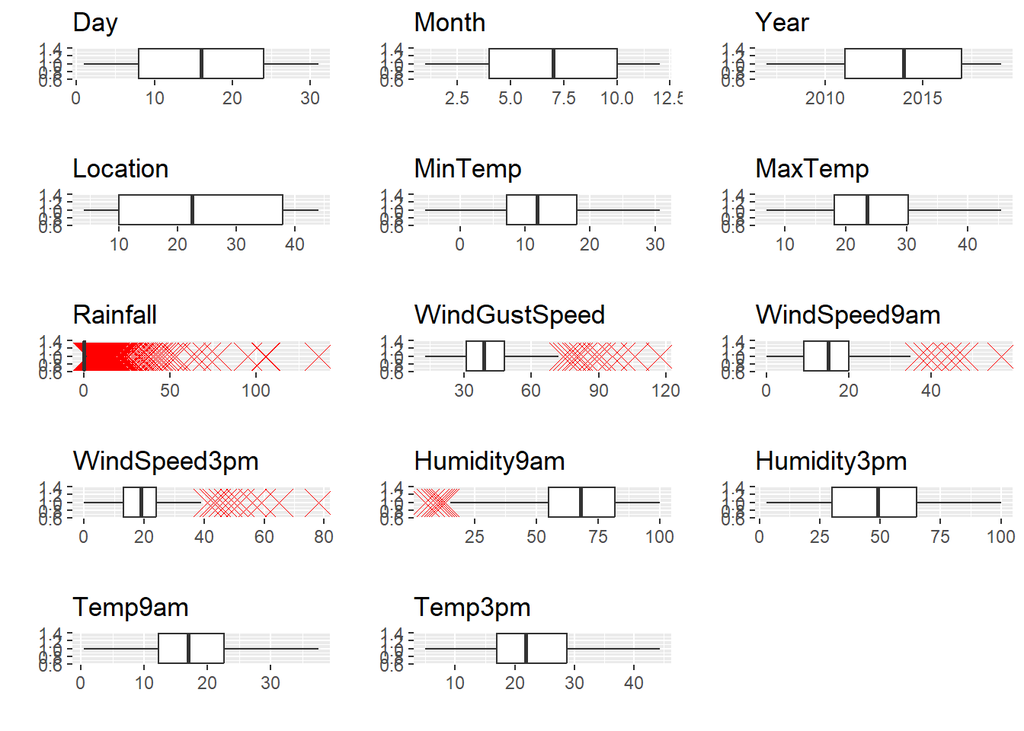

```r
#Defining Boxplot Function
library(ggplot2, quietly = TRUE)

boxplot1 <- function (vars, title){
  ggplot(numerical, aes(x = vars, y = 1)) +
    geom_boxplot(outlier.colour = "red", outlier.shape = 4, outlier.size = 6) +
    ggtitle(title) + labs(x = " ", y = " ")
}

#Plotting Boxplot for All Numerical Variables
Day <- boxplot1(numerical$Day, "Day")
Month <- boxplot1(numerical$Month, "Month")
Year <- boxplot1(numerical$Year, "Year")
Location <- boxplot1(numerical$Location, "Location")
MinTemp <- boxplot1(numerical$MinTemp, "MinTemp")
MaxTemp <- boxplot1(numerical$MaxTemp, "MaxTemp")
Rainfall <- boxplot1(numerical$Rainfall, "Rainfall")
WindGustSpeed <- boxplot1(numerical$WindGustSpeed, "WindGustSpeed")
WindSpeed9am <- boxplot1(numerical$WindSpeed9am, "WindSpeed9am")
WindSpeed3pm <- boxplot1(numerical$WindSpeed3pm, "WindSpeed3pm")
Humidity9am <- boxplot1(numerical$Humidity9am, "Humidity9am")
Humidity3pm <- boxplot1(numerical$Humidity3pm, "Humidity3pm")
Temp9am <- boxplot1(numerical$Temp9am, "Temp9am")
Temp3pm <- boxplot1(numerical$Temp3pm, "Temp3pm")

#Display All Boxplots in Grid
library(cowplot, quietly = TRUE)

plot_grid(Day, Month, Year, Location, MinTemp, MaxTemp, Rainfall, WindGustSpeed, WindSpeed9am, WindSpeed3pm, Humidity9am, Humidity3pm, Temp9am, Temp3pm, nrow = 5)
```

From the boxplots above, “Rainfall”, “WindGustSpeed”, “WindSpeed9am”, “WindSpeed3pm” and “Humidity9am” **have outliers** in their data. The remaining variables are proven to have no outliers. Before proceeding with model training, these outliers should be treated.

In the case of predicting whether tomorrow will rain, such extreme values may be logical as it may be due to extreme whether or the location. Also, since we are random sampling 2000 observations from the original dataset, it is possible to sample data from, for instance, a location with very high temperature or humidity for a particular month, which is logical in the original dataset but is seemed as outlier in our sample dataset. Therefore, these outliers are **not omitted**.

As we have decided not to omit the outliers, regression methods such as linear regression and logistic regression is not applicable in this situation as these methods are very sensitive to extreme values. In this case, tree-based classification methods are more suitable as they can handle non-linear relationships between the predictor variables and the response variable.

Lastly, we will check the correlation between the independent variables.

## Correlation

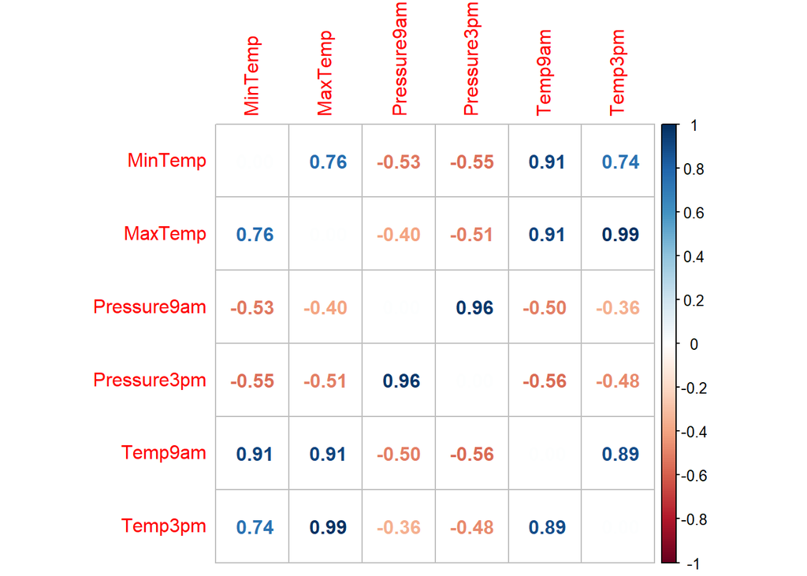

```r
#Plotting Correlations Greater than 0.8
library(purrr, quietly = TRUE)
library(corrplot, quietly = TRUE)
numeric <- map_lgl(WAUS, is.numeric) #Extract All Numeric Variables
corr <- cor(WAUS[, numeric]) #Calculate Correlation between Variables
diag(corr) <- 0 #Set the Diagonal of Heat Map as 0
high_value <- apply(abs(corr) >= 0.8, 2, any) #Extract Variables with Correlation > 0.8
corrplot(corr[high_value, high_value], method = "number") #Plot Variables with Correlation > 0.8
```

Based on the heat map above, “MinTemp”, “MaxTemp”, “Temp9am” and “Temp3pm” are **highly correlated** with each other. In this case, its treatment depends on how good each variable in differentiating whether it will rain tomorrow.

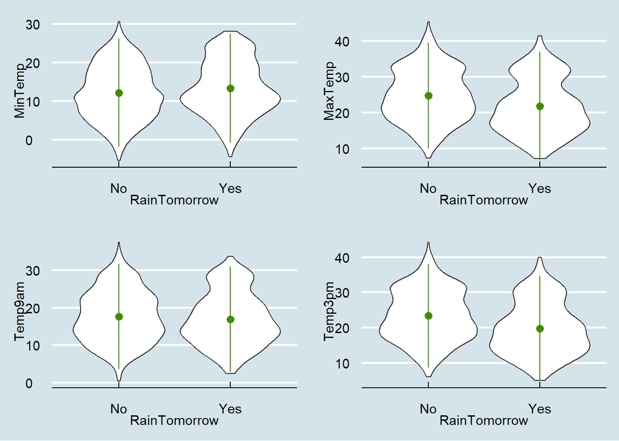

```r
#Drawing Boxplot to Visualize Whether Each Variable Differentiates Itself in Deciding whether It Will Rain Tomorrow
library(ggthemes, quietly = TRUE)
#Function for Boxplot
boxplot2 <- function(vars, title){
  ggplot(WAUS, aes(x = RainTomorrow, y = vars)) +
    geom_violin() +
    theme_economist() +
    stat_summary(fun.data = mean_sdl, geom = "pointrange", colour = "chartreuse4") +
    ylab(title)
}

#Plotting Boxplot for the Highly Correlated Variables
mintemp <- boxplot2(WAUS$MinTemp, "MinTemp")
maxtemp <- boxplot2(WAUS$MaxTemp, "MaxTemp")
temp9 <- boxplot2(WAUS$Temp9am, "Temp9am")
temp3 <- boxplot2(WAUS$Temp3pm, "Temp3pm")

#Display Boxplots in Grid
plot_grid(mintemp, maxtemp, temp9, temp3, nrow = 2, ncol = 2)
```

Based on the graph above, there is no single variable outperform others in differentiating whether tomorrow will rain, thus only one variable will be kept and the remaining 3 will be removed.

The decision to maintained one variable while removing the other highly correlated variables are based on [discussion by Saabas](http://blog.datadive.net/selecting-good-features-part-iii-random-forests/). For impurity based ranking models such as random forest, when the data has two or more correlated features, the model will “think” that any of these correlated features can be used as the predictor, with no concrete preference over the others. But once one of them is used, the importance of others is significantly reduced since effectively the impurity they can remove is already removed by the first feature. As a consequence, they will have a lower reported importance.

When interpreting the data, this can lead to the incorrect conclusion that one of the variables is a strong predictor while the others in the same group are unimportant, while actually they are very close in terms of their relationship with the response variable.

Not only that, according to [Brownlee](https://machinelearningmastery.com/better-naive-bayes/), the performance of Naive Bayes can degrade if the data contains highly correlated features. This is because the highly correlated features are voted for twice in the model, over inflating their importance.

In this case, **“Temp9am”** is chosen as the variable to be remained and the remaining 3 variables are removed.

```r
#Remove Highly Correlated Variables
library(magrittr, quietly = TRUE)
WAUS %<>% select(-MinTemp, -MaxTemp, -Temp3pm)
```

Similarly, “Pressure9am” and “Pressure3pm” are also highly correlated.

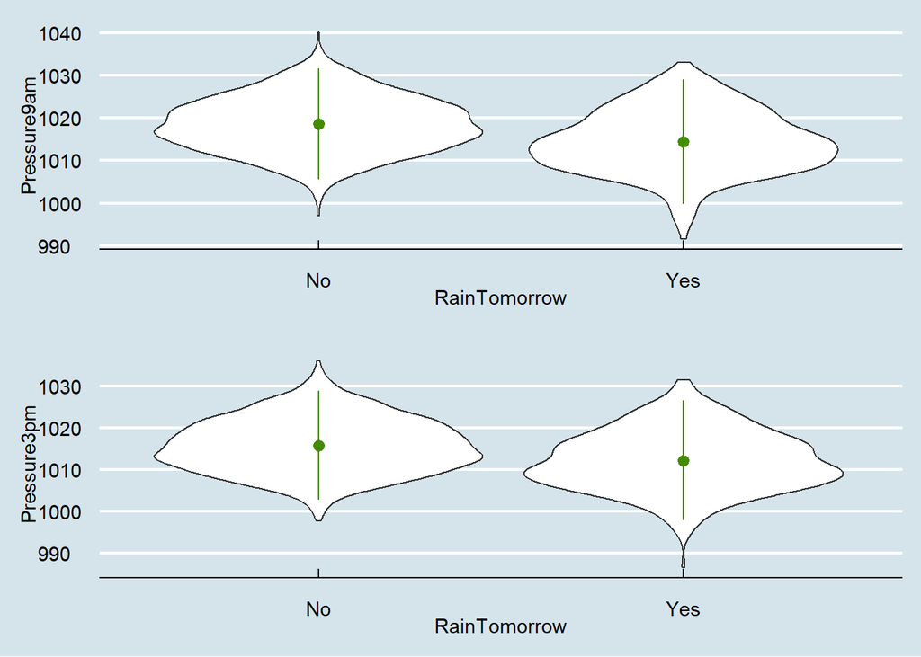

```r
#Plotting Boxplot for the Highly Correlated Variables
pressure9 <- boxplot2(WAUS$Pressure9am, "Pressure9am")
pressure3 <- boxplot2(WAUS$Pressure3pm, "Pressure3pm")

#Display Boxplots in Grid
plot_grid(pressure9, pressure3, nrow = 2, ncol = 1)
```

Similarly, there is no single variable outperform others in differentiating whether tomorrow will rain, thus only one variable will be kept and the other will be removed. In this case, **Pressure9am** is retained and **Pressure3pm** is removed.

```r
WAUS %<>% select(-Pressure3pm)
```

# Classification Model Implementation

## Segregate Data into Training and Test Set

After data cleaning and preprocessing, classification model is implemented to predict whether it will rain tomorrow. The data is segregated into a training set and a test set.

```r
set.seed(100)
train.row = sample(1:nrow(WAUS), 0.7 * nrow(WAUS))
WAUS.train = WAUS[train.row, ]
WAUS.test = WAUS[-train.row, ]
```

## Classification Model

Classification models are then implemented on the segregated data. After implementing the models, a confusion matrix is constructed and a few important indicators are determined:

1. **Accuracy** Accuracy is the ratio of correctly predicted observation to the total observation. A higher accuracy suggests lower training error rate.
2. **Precision** Precision is the ratio of correctly predicted positive observations to the total predicted positive observations. A higher precision indicates that the model has a lower false positive rate.
3. **Recall** Recall is the ratio of correctly predicted positive observations to all the observations in the actual class.
4. **F1** F1 score is the weighted average of Precision and Recall. Therefore, this score takes both false positives and false negatives into account.

In general, a higher value for these indicators are preferable.

Not only that, from the confusion matrix, we would also like to determine: 1. **True Positive Rate** True positive is the outcome where the model correctly predicts the positive class.A higher true positive rate is always preferable.

2. **True Negative Rate** True negative is the outcome where the model correctly predicts the negative class.A higher true negative rate is always preferable.
3. **Type I Error / False Positive Rate** Type I Error occurs when the model incorrectly rejects the true null hypothesis. In this case, it means that the model predict that it will not rain tomorrow but in reality it does. A lower Type I Error is always preferable.
4. **Type II Error / False Negative Rate** Type II Error occurs when the model fail to reject the false null hypothesis. In this case, it means that the model predict that it will rain tomorrow but in reality it doesn’t. A lower Type II Error is always preferable.

In this project, **5** classification models will be applied. For all classification models, **it will not rain tomorrow** will be viewed as the **positive class**, while **it will rain tomorrow** the **negative class**.

### 1. Decision Tree

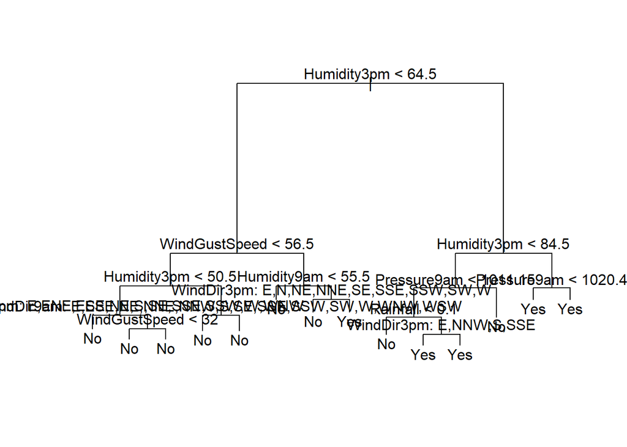

```r
#Calculating a Decision Tree
library(tree, quietly = TRUE)
set.seed(100)
WAUS.tree <- tree(RainTomorrow ~ ., data = WAUS.train)

#Visualizing decision tree
{
 plot(WAUS.tree)
 text(WAUS.tree, pretty = 0)
}
```

```r
#Predictions and Construct Confusion Matrix
set.seed(100)
WAUS.predtree <- predict(WAUS.tree, WAUS.test, type = "class") #Prediction

library(caret, quietly = TRUE)
library(e1071, quietly = TRUE)

CM.tree <- confusionMatrix(mode = "prec_recall", data = WAUS.predtree, reference = WAUS.test$RainTomorrow) #Confusion Matrix
print(CM.tree)
```

```
## Confusion Matrix and Statistics
##
##           Reference
## Prediction  No Yes
##        No  452  88
##        Yes  18  42
##
##                Accuracy : 0.8233
##                  95% CI : (0.7904, 0.853)
##     No Information Rate : 0.7833
##     P-Value [Acc > NIR] : 0.008784
##
##                   Kappa : 0.3537
##
##  Mcnemar's Test P-Value : 2.058e-11
##
##               Precision : 0.8370
##                  Recall : 0.9617
##                      F1 : 0.8950
##              Prevalence : 0.7833
##          Detection Rate : 0.7533
##    Detection Prevalence : 0.9000
##       Balanced Accuracy : 0.6424
##
##        'Positive' Class : No
##
```

Based on the confusion matrix, the accuracy of Decision Tree model is **82.33%**.

```r
#Calculating Type I Error
T1.tree <- CM.tree$table[3] / (CM.tree$table[3] + CM.tree$table[4])

#Calculating Type II Error
T2.tree <- 1 - (CM.tree$table[1] / (CM.tree$table[1] + CM.tree$table[2]))

#Calculating True Positive Rate
TP.tree <- 1 - T2.tree

#Calculating True Negative Rate
TN.tree <- 1 - T1.tree

#Constructing Summary Table for Decision Tree
t1 <- rbind(CM.tree$overall['Accuracy'], CM.tree$byClass['Pos Pred Value'], CM.tree$byClass['Sensitivity'], CM.tree$byClass['F1'], T1.tree, T2.tree, TP.tree, TN.tree)

rownames(t1) = c("Accuracy", "Precision", "Recall", "F1", "Type I Error", "Type II Error", "True Positive", "True Negative")
colnames(t1) = "Decision Tree"

library(knitr, quietly = TRUE)
library(kableExtra, quietly = TRUE)
t1 %>% kable() %>% kable_styling("responsive")
```

|  | Decision Tree |
| --- | --- |
| Accuracy | 0.8233333 |
| Precision | 0.8370370 |
| Recall | 0.9617021 |
| F1 | 0.8950495 |
| Type I Error | 0.6769231 |
| Type II Error | 0.0382979 |
| True Positive | 0.9617021 |
| True Negative | 0.3230769 |

From t1, we can see that, while Decision Tree has accuracy, precision, recall and F1 Score approximately 80% and above, high True Positive and low Type II Error, it does have a problem of **higher Type I Error**, which means that this model may be insufficient in correctly predicting True Negative values, which, in this case, it may wrongly predict that it will not rain tomorrow while in reality it rains tomorrow.

### 2. Naive Bayes

```r
#Implementing Naive Bayes
library(e1071, quietly = TRUE)
set.seed(100)
WAUS.bayes <- naiveBayes(RainTomorrow ~ ., data = WAUS.train)

#Prediction and Construct Confusion Matrix
set.seed(100)
WAUS.predbayes <- predict(WAUS.bayes, WAUS.test) #Prediction

CM.bayes <- confusionMatrix(mode = "prec_recall", data = WAUS.predbayes, reference = WAUS.test$RainTomorrow) #Confusion Matrix
print(CM.bayes)
```

```
## Confusion Matrix and Statistics
##
##           Reference
## Prediction  No Yes
##        No  423  67
##        Yes  47  63
##
##                Accuracy : 0.81
##                  95% CI : (0.7763, 0.8406)
##     No Information Rate : 0.7833
##     P-Value [Acc > NIR] : 0.06060
##
##                   Kappa : 0.4073
##
##  Mcnemar's Test P-Value : 0.07516
##
##               Precision : 0.8633
##                  Recall : 0.9000
##                      F1 : 0.8812
##              Prevalence : 0.7833
##          Detection Rate : 0.7050
##    Detection Prevalence : 0.8167
##       Balanced Accuracy : 0.6923
##
##        'Positive' Class : No
##
```

Based on the confusion matrix, the accuracy of Naive Bayes is **81.00%**.

```r
#Calculating Type I Error
T1.bayes <- CM.bayes$table[3] / (CM.bayes$table[3] + CM.bayes$table[4])

#Calculating Type II Error
T2.bayes <- 1 - (CM.bayes$table[1] / (CM.bayes$table[1] + CM.bayes$table[2]))

#Calculating True Positive Rate
TP.bayes <- 1 - T2.bayes

#Calculating True Negative Rate
TN.bayes <- 1 - T1.bayes

#Constructing Summary Table for Naive Bayes
t2 <- rbind(CM.bayes$overall['Accuracy'], CM.bayes$byClass['Pos Pred Value'], CM.bayes$byClass['Sensitivity'], CM.bayes$byClass['F1'], T1.bayes, T2.bayes, TP.bayes, TN.bayes)

rownames(t2) = c("Accuracy", "Precision", "Recall", "F1", "Type I Error", "Type II Error", "True Positive", "True Negative")
colnames(t2) = "Naive Bayes"

t2 %>% kable() %>% kable_styling("responsive")
```

|  | Naive Bayes |
| --- | --- |
| Accuracy | 0.8100000 |
| Precision | 0.8632653 |
| Recall | 0.9000000 |
| F1 | 0.8812500 |
| Type I Error | 0.5153846 |
| Type II Error | 0.1000000 |
| True Positive | 0.9000000 |
| True Negative | 0.4846154 |

Similar to Decision Tree, Naive Bayes has **higher Type I Error**, indicating that this model may wrongly predict that it will not rain tomorrow while in reality it rains tomorrow.

### 3. Bagging

```r
#Implementing Bagging
library(ipred, quietly = TRUE)
library(adabag, quietly = TRUE)
set.seed(100)
WAUS.bag <- bagging(RainTomorrow ~ ., data = WAUS.train, mfinal = 10)

#Prediction and Construct Confusion Matrix
set.seed(100)
WAUS.predbag <- predict.bagging(WAUS.bag, WAUS.test) #Prediction

CM.bag <- confusionMatrix(mode = "prec_recall", WAUS.predbag$confusion) #Confusion Matrix
print(CM.bag)
```

```
## Confusion Matrix and Statistics
##
##                Observed Class
## Predicted Class  No Yes
##             No  448  74
##             Yes  22  56
##
##                Accuracy : 0.84
##                  95% CI : (0.8082, 0.8684)
##     No Information Rate : 0.7833
##     P-Value [Acc > NIR] : 0.0003041
##
##                   Kappa : 0.4489
##
##  Mcnemar's Test P-Value : 1.938e-07
##
##               Precision : 0.8582
##                  Recall : 0.9532
##                      F1 : 0.9032
##              Prevalence : 0.7833
##          Detection Rate : 0.7467
##    Detection Prevalence : 0.8700
##       Balanced Accuracy : 0.6920
##
##        'Positive' Class : No
##
```

Based on the confusion matrix, the accuracy of Bagging is **84.00%**.

```r
#Calculating Type I Error
T1.bag <- CM.bag$table[3] / (CM.bag$table[3] + CM.bag$table[4])

#Calculating Type II Error
T2.bag <- 1 - (CM.bag$table[1] / (CM.bag$table[1] + CM.bag$table[2]))

#Calculating True Positive Rate
TP.bag <- 1 - T2.bag

#Calculating True Negative Rate
TN.bag <- 1 - T1.bag

#Constructing Summary Table for Bagging
t3 <- rbind(CM.bag$overall['Accuracy'], CM.bag$byClass['Pos Pred Value'], CM.bag$byClass['Sensitivity'], CM.bag$byClass['F1'], T1.bag, T2.bag, TP.bag, TN.bag)

rownames(t3) = c("Accuracy", "Precision", "Recall", "F1", "Type I Error", "Type II Error", "True Positive", "True Negative")
colnames(t3) = "Bagging"

t3 %>% kable() %>% kable_styling("responsive")
```

|  | Bagging |
| --- | --- |
| Accuracy | 0.8400000 |
| Precision | 0.8582375 |
| Recall | 0.9531915 |
| F1 | 0.9032258 |
| Type I Error | 0.5692308 |
| Type II Error | 0.0468085 |
| True Positive | 0.9531915 |
| True Negative | 0.4307692 |

Similar to both Decision Tree and Naive Bayes, Bagging has a **higher Type I Error**, indicating that this model may wrongly predict that it will not rain tomorrow while in reality it rains tomorrow.

### 4. Boosting

```r
#Boosting
library(adabag, quietly = TRUE)
set.seed(100)
WAUS.boost <- boosting(RainTomorrow ~ ., data = WAUS.train, mfinal = 10)

#Prediction and Construct Confusion Matrix
set.seed(100)
WAUS.predboost <- predict.boosting(WAUS.boost, WAUS.test) #Prediction

CM.boost <- confusionMatrix(mode = "prec_recall", WAUS.predboost$confusion) #Confusion Matrix
print(CM.boost)
```

```
## Confusion Matrix and Statistics
##
##                Observed Class
## Predicted Class  No Yes
##             No  428  76
##             Yes  42  54
##
##                Accuracy : 0.8033
##                  95% CI : (0.7692, 0.8344)
##     No Information Rate : 0.7833
##     P-Value [Acc > NIR] : 0.126587
##
##                   Kappa : 0.3601
##
##  Mcnemar's Test P-Value : 0.002382
##
##               Precision : 0.8492
##                  Recall : 0.9106
##                      F1 : 0.8789
##              Prevalence : 0.7833
##          Detection Rate : 0.7133
##    Detection Prevalence : 0.8400
##       Balanced Accuracy : 0.6630
##
##        'Positive' Class : No
##
```

Based on the confusion matrix, the accuracy of Boosting is **80.33%**.

```r
#Calculating Type I Error
T1.boost <- CM.boost$table[3] / (CM.boost$table[3] + CM.boost$table[4])

#Calculating Type II Error
T2.boost <- 1 - (CM.boost$table[1] / (CM.boost$table[1] + CM.boost$table[2]))

#Calculating True Positive Rate
TP.boost <- 1 - T2.boost

#Calculating True Negative Rate
TN.boost <- 1 - T1.boost

#Constructing Summary Table for Boosting
t4 <- rbind(CM.boost$overall['Accuracy'], CM.boost$byClass['Pos Pred Value'], CM.boost$byClass['Sensitivity'], CM.boost$byClass['F1'], T1.boost, T2.boost, TP.boost, TN.boost)

rownames(t4) = c("Accuracy", "Precision", "Recall", "F1", "Type I Error", "Type II Error", "True Positive", "True Negative")
colnames(t4) = "Boosting"

t4 %>% kable() %>% kable_styling("responsive")
```

|  | Boosting |
| --- | --- |
| Accuracy | 0.8033333 |
| Precision | 0.8492063 |
| Recall | 0.9106383 |
| F1 | 0.8788501 |
| Type I Error | 0.5846154 |
| Type II Error | 0.0893617 |
| True Positive | 0.9106383 |
| True Negative | 0.4153846 |

Similar to the three methods above, Boosting has a **higher Type I Error**, indicating that this model may wrongly predict that it will not rain tomorrow while in reality it rains tomorrow.

### 5. Random Forest

```r
#Implementing Random Forest
library(randomForest, quietly = TRUE)
set.seed(100)
WAUS.rf <- randomForest(RainTomorrow ~ ., data = WAUS.train)

#Prediction and Construct Confusion Matrix
set.seed(100)
WAUS.predrf <- predict(WAUS.rf, WAUS.test) #Prediction

CM.rf <- confusionMatrix(mode = "prec_recall", data = WAUS.predrf, reference = WAUS.test$RainTomorrow) #Confusion Matrix
print(CM.rf)
```

```
## Confusion Matrix and Statistics
##
##           Reference
## Prediction  No Yes
##        No  440  67
##        Yes  30  63
##
##                Accuracy : 0.8383
##                  95% CI : (0.8064, 0.8669)
##     No Information Rate : 0.7833
##     P-Value [Acc > NIR] : 0.0004479
##
##                   Kappa : 0.4691
##
##  Mcnemar's Test P-Value : 0.0002569
##
##               Precision : 0.8679
##                  Recall : 0.9362
##                      F1 : 0.9007
##              Prevalence : 0.7833
##          Detection Rate : 0.7333
##    Detection Prevalence : 0.8450
##       Balanced Accuracy : 0.7104
##
##        'Positive' Class : No
##
```

Based on the confusion matrix, the accuracy of Random Forest is **83.83%**.

```r
#Calculating Type I Error
T1.rf <- CM.rf$table[3] / (CM.rf$table[3] + CM.rf$table[4])

#Calculating Type II Error
T2.rf <- 1 - (CM.rf$table[1] / (CM.rf$table[1] + CM.rf$table[2]))

#Calculating True Positive Rate
TP.rf <- 1 - T2.rf

#Calculating True Negative Rate
TN.rf <- 1 - T1.rf

#Constructing Summary Table for Random Forest
t5 <- rbind(CM.rf$overall['Accuracy'], CM.rf$byClass['Pos Pred Value'], CM.rf$byClass['Sensitivity'], CM.rf$byClass['F1'], T1.rf, T2.rf, TP.rf, TN.rf)

rownames(t5) = c("Accuracy", "Precision", "Recall", "F1", "Type I Error", "Type II Error", "True Positive", "True Negative")
colnames(t5) = "Random Forest"

t5 %>% kable() %>% kable_styling("responsive")
```

|  | Random Forest |
| --- | --- |
| Accuracy | 0.8383333 |
| Precision | 0.8678501 |
| Recall | 0.9361702 |
| F1 | 0.9007165 |
| Type I Error | 0.5153846 |
| Type II Error | 0.0638298 |
| True Positive | 0.9361702 |
| True Negative | 0.4846154 |

## ROC Curve and Area Under the Curve (AUC)

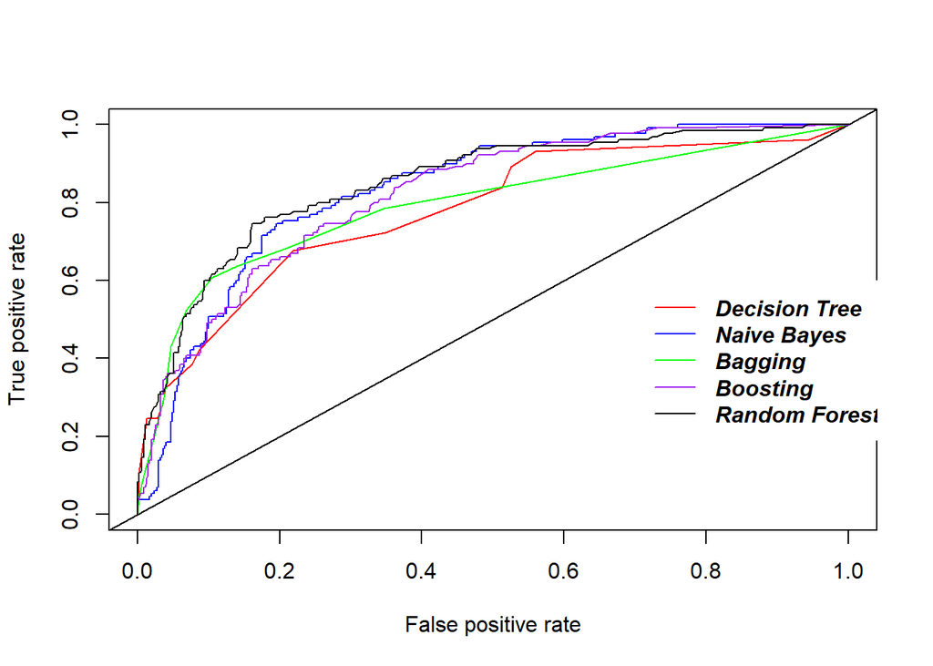

```r
library(ROCR, quietly = TRUE)
#ROC for Decision Tree
WAUS.prob.tree <- predict(WAUS.tree, WAUS.test, type = "vector") #Prediction as Probability
WAUSpredtree <- prediction(WAUS.prob.tree[, 2], WAUS.test$RainTomorrow)
WAUSperftree <- performance(WAUSpredtree, "tpr", "fpr")

#ROC for Naive Bayes
WAUS.prob.bayes <- predict(WAUS.bayes, WAUS.test, type = "raw")
WAUSpredbayes <- prediction(WAUS.prob.bayes[, 2], WAUS.test$RainTomorrow)
WAUSperfbayes <- performance(WAUSpredbayes, "tpr", "fpr")

#ROC for Bagging
WAUSpredbag <- prediction(WAUS.predbag$prob[, 2], WAUS.test$RainTomorrow)
WAUSperfbag <- performance(WAUSpredbag, "tpr", "fpr")

#ROC for Boosting
WAUSpredboost <- prediction(WAUS.predboost$prob[, 2], WAUS.test$RainTomorrow)
WAUSperfboost <- performance(WAUSpredboost, "tpr", "fpr")

#Roc for Random Forest
WAUS.prob.rf <- predict(WAUS.rf, WAUS.test, type = "prob")
WAUSpredrf <- prediction(WAUS.prob.rf[, 2], WAUS.test$RainTomorrow)
WAUSperfrf <- performance(WAUSpredrf, "tpr", "fpr")

#Plot ROC for All Classifiers
{plot(WAUSperftree, col = "red")
 abline(0, 1)
 plot(WAUSperfbayes, add = TRUE, col = "blue")
 plot(WAUSperfbag, add = TRUE, col = "green")
 plot(WAUSperfboost, add = TRUE, col = "purple")
 plot(WAUSperfrf, add = TRUE, col = "black")
 legend(x = 0.7, y = 0.6, lty = 1, legend = c("Decision Tree", "Naive Bayes", "Bagging", "Boosting", "Random Forest"), col = c("red", "blue", "green", "purple", "black"), text.font = 4, box.lty = 0)
}
```

ROC Curve for all 5 classifiers are plotted in the graph above.

```r
#Calculating AUC for All Curves
#Decision Tree
AUC.tree <- performance(WAUSpredtree, "auc")
AUC.tree <- round(as.numeric(AUC.tree@y.values), 4)

#Naive Bayes
AUC.bayes <- performance(WAUSpredbayes, "auc")
AUC.bayes <- round(as.numeric(AUC.bayes@y.values), 4)

#Bagging
AUC.bag <- performance(WAUSpredbag, "auc")
AUC.bag <- round(as.numeric(AUC.bag@y.values), 4)

#Boosting
AUC.boost <- performance(WAUSpredboost, "auc")
AUC.boost <- round(as.numeric(AUC.boost@y.values), 4)

#Random Forest
AUC.rf <- performance(WAUSpredrf, "auc")
AUC.rf <- round(as.numeric(AUC.rf@y.values), 4)

#Tabulate All AUC Values
AUC.table <- cbind(AUC.tree, AUC.bayes, AUC.bag, AUC.boost, AUC.rf)
rownames(AUC.table) <- "AUC"
colnames(AUC.table) <- c("Decision Tree", "Naive Bayes", "Bagging", "Boosting", "Random Forest")
AUC.table %>% kable() %>% kable_styling("responsive")
```

|  | Decision Tree | Naive Bayes | Bagging | Boosting | Random Forest |
| --- | --- | --- | --- | --- | --- |
| AUC | 0.7784 | 0.8321 | 0.7921 | 0.8207 | 0.8499 |

AUC for all 5 classifiers are summarized in the table above. To simplify comparison, a summary table consist of all important information from confusion matrix and AUC for all 5 classifiers are generated.

```r
#Tabulate All Information in One Table
summary.table <- cbind(t1, t2[1:8, ], t3[1:8, ], t4[1:8, ], t5[1:8, ])
summary.table <- rbind(summary.table, AUC.table)
summary.table <- round(summary.table, 4)
colnames(summary.table) <- c("Decision Tree", "Naive Bayes", "Bagging", "Boosting", "Random Forest")

#Identify the Highest Value among the 5 Classifiers
row <- seq_len(ncol(summary.table))

{
max.acc <- which.max(summary.table[1, ])
summary.table[1, ] <- summary.table[1, ] %>% cell_spec(bold = row == max.acc)

max.prec <- which.max(summary.table[2, ])
summary.table[2, ] <- summary.table[2, ] %>% cell_spec(bold = row == max.prec)

max.rec <- which.max(summary.table[3, ])
summary.table[3, ] <- summary.table[3, ] %>% cell_spec(bold = row == max.rec)

max.f1 <- which.max(summary.table[4, ])
summary.table[4, ] <- summary.table[4, ] %>% cell_spec(bold = row == max.f1)

max.tp <- which.max(summary.table[7, ])
summary.table[7, ] <- summary.table[7, ] %>% cell_spec(bold = row == max.tp)

max.tn <- which.max(summary.table[8, ])
summary.table[8, ] <- summary.table[8, ] %>% cell_spec(bold = row == max.tn)

max.auc <- which.max(summary.table[9, ])
summary.table[9, ] <- summary.table[9, ] %>% cell_spec(bold = row == max.auc)

#Identify the Smallest Value among the 5 Classifiers
min.t1 <- which.min(summary.table[5, ])
summary.table[5, ] <- summary.table[5, ] %>% cell_spec(bold = row == min.t1)

min.t2 <- which.min(summary.table[6, ])
summary.table[6, ] <- summary.table[6, ] %>% cell_spec(bold = row == min.t2)
}


summary.table %>% kable(booktabs = TRUE, escape = FALSE) %>% kable_styling("responsive")
```

|  | Decision Tree | Naive Bayes | Bagging | Boosting | Random Forest |
| --- | --- | --- | --- | --- | --- |
| Accuracy | 0.8233 | 0.81 | 0.84 | 0.8033 | 0.8383 |
| Precision | 0.837 | 0.8633 | 0.8582 | 0.8492 | 0.8679 |
| Recall | 0.9617 | 0.9 | 0.9532 | 0.9106 | 0.9362 |
| F1 | 0.895 | 0.8812 | 0.9032 | 0.8789 | 0.9007 |
| Type I Error | 0.6769 | 0.5154 | 0.5692 | 0.5846 | 0.5154 |
| Type II Error | 0.0383 | 0.1 | 0.0468 | 0.0894 | 0.0638 |
| True Positive | 0.9617 | 0.9 | 0.9532 | 0.9106 | 0.9362 |
| True Negative | 0.3231 | 0.4846 | 0.4308 | 0.4154 | 0.4846 |
| AUC | 0.7784 | 0.8321 | 0.7921 | 0.8207 | 0.8499 |

## Variable Performance Evaluation

```r
#Attribute Importance
{cat("\nDecision Tree Attribute Importance\n")
 print(summary(WAUS.tree))
 cat("\nBagging Attribute Importance\n")
 print(WAUS.bag$importance)
 cat("\nBoosting Attribute Importance\n")
 print(WAUS.boost$importance)
 cat("\nRandom Forest Attribute Importance\n")
 print(WAUS.rf$importance)
}
```

```
##
## Decision Tree Attribute Importance
##
## Classification tree:
## tree(formula = RainTomorrow ~ ., data = WAUS.train)
## Variables actually used in tree construction:
## [1] "Humidity3pm"   "WindGustSpeed" "WindDir3pm"    "WindDir9am"
## [5] "Humidity9am"   "Pressure9am"   "Rainfall"
## Number of terminal nodes:  14
## Residual mean deviance:  0.6339 = 878.5 / 1386
## Misclassification error rate: 0.13 = 182 / 1400
##
## Bagging Attribute Importance
##           Day   Humidity3pm   Humidity9am      Location         Month
##     0.3277615    42.6681627     1.9610702     0.4427289     0.0000000
##   Pressure9am      Rainfall     RainToday       Temp9am    WindDir3pm
##     8.7276362     2.2748536     0.0000000     1.3708878    10.8445670
##    WindDir9am   WindGustDir WindGustSpeed  WindSpeed3pm  WindSpeed9am
##    11.7317315     9.3040399     8.4389109     0.4615890     0.7259147
##          Year
##     0.7201461
##
## Boosting Attribute Importance
##           Day   Humidity3pm   Humidity9am      Location         Month
##     3.2503050    22.7688017     2.0658498     1.0962783     0.4721068
##   Pressure9am      Rainfall     RainToday       Temp9am    WindDir3pm
##     5.4488980     3.0116860     0.0000000     3.3290585    14.4722784
##    WindDir9am   WindGustDir WindGustSpeed  WindSpeed3pm  WindSpeed9am
##    15.4395100    14.1336230     8.9248826     2.8367745     1.0789682
##          Year
##     1.6709791
##
## Random Forest Attribute Importance
##               MeanDecreaseGini
## Day                   18.55337
## Month                 11.19435
## Year                  12.25689
## Location              10.09728
## Rainfall              27.94685
## WindGustDir           41.31452
## WindGustSpeed         31.89089
## WindDir9am            43.10488
## WindDir3pm            43.59853
## WindSpeed9am          13.81591
## WindSpeed3pm          17.25010
## Humidity9am           37.85914
## Humidity3pm           85.68427
## Pressure9am           37.21963
## Temp9am               20.45651
## RainToday             10.30919
```

# Further Modifications

As there is no classifier that outperforms others, additional attempts are required.

## Improvizing Tree-Based Classifier

One potential way is to tune the hyperparameter of existing model, in hope to find the best classifier to predict whether it will rain tomorrow. In this case, the **Random Forest** classifier is chosen to be fine-tuned because it is a theoretically better model than decision tree, bagging and boosting that combines the strengths of these methods while minimizing their weaknesses.

In terms of decision trees, random forest reduces the tendency of a decision tree to overfit the training data by constructing a multitude of decision trees with random subsets of the features and training data, and then averaging the results to obtain a more robust prediction.

Bagging and boosting are also ensemble methods like random forest, but they focus on a single decision tree, while random forest combines multiple decision trees. Bagging is a method of creating multiple bootstrapped training sets from the original dataset, and then constructing a decision tree for each set. Boosting, on the other hand, iteratively adjusts the weights of the training data points to improve the classification accuracy.

Therefore, comparing all 4 classifiers, fine-tuning random forest has the best chance of discovering the best model for predicting whether it will rain tomorrow.

To improve the Random Forest classifier, a **k-Fold Cross Validated Random Forest** is proposed to identify the optimal $mtry$ for Random Forest. In the caret package, $mtry$ can be tuned using either “random” or “grid” search strategy. In this case, the **grid search algorithm** is used because it is more likely to find the optimal hyperparameters for the model, since it explores the entire hyperparameter space systematically. Although it comes at the cost of computational efficiency, especially for high-dimensional hyperparameter spaces, the benefit would still outweight the cost for a relatively small dataset.

Grid search is the process of performing hyper parameter tuning in order to determine the optimal values for a given model. Each axis of the grid is an algorithm parameter, and points in the grid are specific combinations of parameters. Because we are only tuning one parameter, the grid search is a linear search through a vector of candidate values.

```r
#Varying mtry to Decide the optimal mtry
library(caret, quietly = TRUE)

#Grid Search
set.seed(100)
trctrl <- trainControl(method = "repeatedcv", number = 10, repeats = 3, search = "grid")
tunegrid <- expand.grid(.mtry = (1:15))
cvrf.grid <- train(RainTomorrow ~ ., data = WAUS.train, method = "rf", metric = 'Accuracy', tuneGrid = tunegrid, trControl = trctrl)
print(cvrf.grid)
```

```
## Random Forest
##
## 1400 samples
##   16 predictor
##    2 classes: 'No', 'Yes'
##
## No pre-processing
## Resampling: Cross-Validated (10 fold, repeated 3 times)
## Summary of sample sizes: 1260, 1260, 1260, 1260, 1261, 1261, ...
## Resampling results across tuning parameters:
##
##   mtry  Accuracy   Kappa
##    1    0.7914325  0.0000000
##    2    0.8309722  0.2789241
##    3    0.8473958  0.3907868
##    4    0.8535779  0.4329500
##    5    0.8538125  0.4449087
##    6    0.8552411  0.4595054
##    7    0.8573823  0.4733008
##    8    0.8576120  0.4767645
##    9    0.8583279  0.4823100
##   10    0.8564198  0.4784399
##   11    0.8564232  0.4781643
##   12    0.8561885  0.4811660
##   13    0.8580881  0.4869382
##   14    0.8552327  0.4776250
##   15    0.8566544  0.4850882
##
## Accuracy was used to select the optimal model using the largest value.
## The final value used for the model was mtry = 9.
```

From the results, it is identified that $mtry = 9$ has the highest accuracy. Therefore, $mtry = 9$ is used for the Random Forest model.

```r
#Prediction and Construct Confusion Matrix
set.seed(100)
WAUS.predrfgrid <- predict(cvrf.grid, WAUS.test) #Prediction

CM.cvrf <- confusionMatrix(mode = "prec_recall", data = WAUS.predrfgrid, reference = WAUS.test$RainTomorrow) #Confusion Matrix
print(CM.cvrf)
```

```
## Confusion Matrix and Statistics
##
##           Reference
## Prediction  No Yes
##        No  445  72
##        Yes  25  58
##
##                Accuracy : 0.8383
##                  95% CI : (0.8064, 0.8669)
##     No Information Rate : 0.7833
##     P-Value [Acc > NIR] : 0.0004479
##
##                   Kappa : 0.4521
##
##  Mcnemar's Test P-Value : 3.003e-06
##
##               Precision : 0.8607
##                  Recall : 0.9468
##                      F1 : 0.9017
##              Prevalence : 0.7833
##          Detection Rate : 0.7417
##    Detection Prevalence : 0.8617
##       Balanced Accuracy : 0.6965
##
##        'Positive' Class : No
##
```

From the confusion matrix above, the accuracy of the model is **83.83%**.

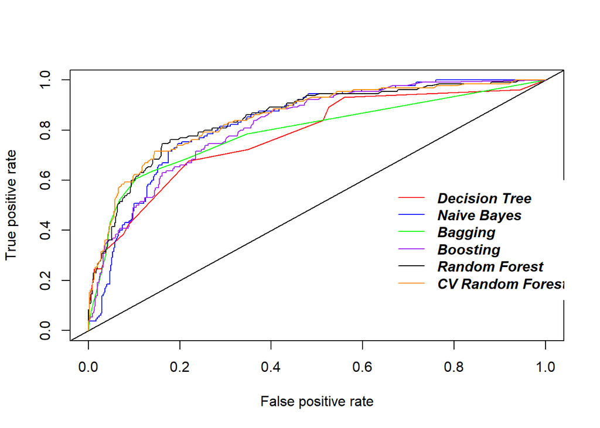

```r
#Calculating Type I Error
T1.cvrf <- CM.cvrf$table[3] / (CM.cvrf$table[3] + CM.cvrf$table[4])

#Calculating Type II Error
T2.cvrf <- 1 - (CM.cvrf$table[1] / (CM.cvrf$table[1] + CM.cvrf$table[2]))

#Calculating True Positive Rate
TP.cvrf <- 1 - T2.cvrf

#Calculating True Negative Rate
TN.cvrf <- 1 - T1.cvrf

#Constructing ROC Curve
WAUS.prob.cvrf <- predict(cvrf.grid, WAUS.test, type = "prob")
WAUSpredcvrf <- ROCR::prediction(WAUS.prob.cvrf[, 2], WAUS.test$RainTomorrow)
WAUSperfcvrf <- performance(WAUSpredcvrf, "tpr", "fpr")

#Plot ROC for All Classifiers
{plot(WAUSperftree, col = "red")
 abline(0, 1)
 plot(WAUSperfbayes, add = TRUE, col = "blue")
 plot(WAUSperfbag, add = TRUE, col = "green")
 plot(WAUSperfboost, add = TRUE, col = "purple")
 plot(WAUSperfrf, add = TRUE, col = "black")
 plot(WAUSperfcvrf, add = TRUE, col = "darkorange")
 legend(x = 0.65, y = 0.6, lty = 1, legend = c("Decision Tree", "Naive Bayes", "Bagging", "Boosting", "Random Forest", "CV Random Forest"), col = c("red", "blue", "green", "purple", "black", "darkorange"), text.font = 4, box.lty = 0)
}
```

The ROC Curve that includes the Cross Validated Random Forest is as illustrated in the figure above.

```r
#Calculating AUC
AUC.cvrf <- performance(WAUSpredcvrf, "auc")
AUC.cvrf <- round(as.numeric(AUC.cvrf@y.values), 4)

#Constructing Summary Table for Cross Validated Random Forest
t6 <- rbind(CM.cvrf$overall['Accuracy'], CM.cvrf$byClass['Pos Pred Value'], CM.cvrf$byClass['Sensitivity'], CM.cvrf$byClass['F1'], T1.cvrf, T2.cvrf, TP.cvrf, TN.cvrf, AUC.cvrf)
t6 <- round(t6, 4)

#Comparing Random Forest and CV Random Forest
summary.table1 <- cbind(t5[1:8, ], t6[1:8, ])
AUC.table1 <- cbind(AUC.rf, AUC.cvrf)
rownames(AUC.table1) <- "AUC"
summary.table1 <- rbind(summary.table1, AUC.table1)
summary.table1 <- round(summary.table1, 4)

colnames(summary.table1) <- c("Random Forest", "CV Random Forest")

#Identify the Highest Value between the Two Classifiers
row <- seq_len(ncol(summary.table1))

{
max.acc <- which.max(summary.table1[1, ])
summary.table1[1, ] <- summary.table1[1, ] %>% cell_spec(bold = row == max.acc)

max.prec <- which.max(summary.table1[2, ])
summary.table1[2, ] <- summary.table1[2, ] %>% cell_spec(bold = row == max.prec)

max.rec <- which.max(summary.table1[3, ])
summary.table1[3, ] <- summary.table1[3, ] %>% cell_spec(bold = row == max.rec)

max.f1 <- which.max(summary.table1[4, ])
summary.table1[4, ] <- summary.table1[4, ] %>% cell_spec(bold = row == max.f1)

max.tp <- which.max(summary.table1[7, ])
summary.table1[7, ] <- summary.table1[7, ] %>% cell_spec(bold = row == max.tp)

max.tn <- which.max(summary.table1[8, ])
summary.table1[8, ] <- summary.table1[8, ] %>% cell_spec(bold = row == max.tn)

max.auc <- which.max(summary.table1[9, ])
summary.table1[9, ] <- summary.table1[9, ] %>% cell_spec(bold = row == max.auc)

#Identify the Smallest Value among the 5 Classifiers
min.t1 <- which.min(summary.table1[5, ])
summary.table1[5, ] <- summary.table1[5, ] %>% cell_spec(bold = row == min.t1)

min.t2 <- which.min(summary.table1[6, ])
summary.table1[6, ] <- summary.table1[6, ] %>% cell_spec(bold = row == min.t2)
}

summary.table1 %>% kable(booktabs = TRUE, escape = FALSE) %>% kable_styling("responsive")
```

|  | Random Forest | CV Random Forest |
| --- | --- | --- |
| Accuracy | 0.8383 | 0.8383 |
| Precision | 0.8679 | 0.8607 |
| Recall | 0.9362 | 0.9468 |
| F1 | 0.9007 | 0.9017 |
| Type I Error | 0.5154 | 0.5538 |
| Type II Error | 0.0638 | 0.0532 |
| True Positive | 0.9362 | 0.9468 |
| True Negative | 0.4846 | 0.4462 |
| AUC | 0.8499 | 0.8511 |

Based on the summary table above, the performance of Cross Validated Random Forest doesn’t differ much from non-cross-validated random forest. This could mean that the model is not overfitting the data.

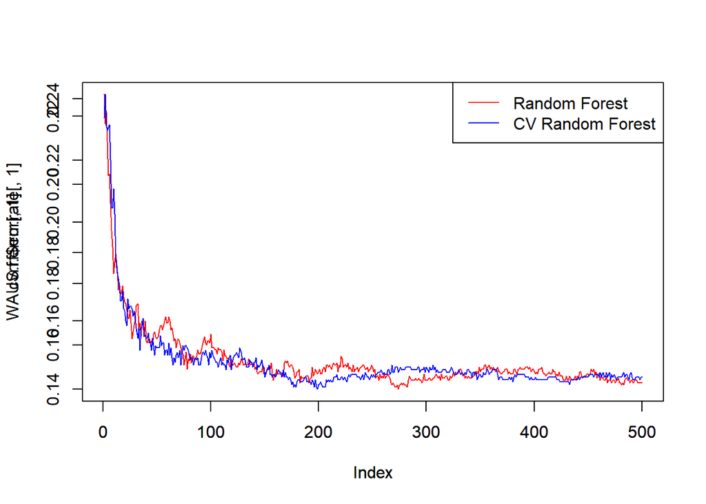

```r
#Out of Bag Error
{
  plot(WAUS.rf$err.rate[, 1], col = "red", type = 'l')
  par(new = TRUE)
  cvrf.error <- as.data.frame(cvrf.grid$finalModel['err.rate'])
  plot(cvrf.error[, 1], col = "blue", type = 'l')
  legend("topright", legend = c("Random Forest", "CV Random Forest"), col = c("red", "blue"), lty = 1)
}
```

Based on the graph above, the Cross Validated Random Forest has almost the same performance as Random Forest in terms of out-of-bag error, suggesting that overfitting is not an issue. In this case, the cross-validated random forest is chosen to be the current best model as cross validation provides a more reliable estimate of the model’s performance.

## Artificial Neural Network

Another consideration is to use Artificial Neural Network (ANN). ANN can be used to predict the class of an input based on its features. The input features are passed through the network, and each neuron performs a weighted sum of the inputs and applies an activation function to produce an output. The outputs of the neurons in the final layer correspond to the predicted class probabilities, and the class with the highest probability is selected as the predicted class.

One of the key strengths of ANNs is **their ability to learn complex non-linear relationships between the input features and the output classes**. This makes ANNs particularly useful for classification tasks where the decision boundary between classes is non-linear or complex. ANNs can also **handle high-dimensional data** and can automatically learn relevant features from the data, all of which are relevant to the training data we possess.

```r
library(neuralnet, quietly = TRUE)
ann.data = WAUS

#Recode Categorical Variable as Numeric
#"RainToday" and "RainTomorrow" (0 - "No", 1 - "Yes")
ann.data$RainToday <- as.numeric(recode(ann.data$RainToday, 'No' = '0','Yes' = '1'))
ann.data$RainTomorrow <- as.numeric(recode(ann.data$RainTomorrow, 'No' = '0','Yes' = '1'))

#"WindGustDir", "WindDir9am" and "WindDir3pm"
#The numeric value of direction follows clockwise direction from 1 - 16
ann.data$WindGustDir <- as.numeric(recode(ann.data$WindGustDir, 'N' = '1','NNE' = '2','NE' = '3','ENE' = '4','E' = '5','ESE' = '6','SE' = '7', 'SSE' = '8','S' = '9','SSW' = '10','SW' = '11', 'WSW' = '12','W' = '13','WNW' = '14', 'NW' = '15','NNW' = '16'))

ann.data$WindDir9am <- as.numeric(recode(ann.data$WindDir9am, 'N' = '1','NNE' = '2','NE' = '3','ENE' = '4','E' = '5','ESE' = '6','SE' = '7', 'SSE' = '8','S' = '9','SSW' = '10','SW' = '11', 'WSW' = '12','W' = '13','WNW' = '14', 'NW' = '15','NNW' = '16'))

ann.data$WindDir3pm <- as.numeric(recode(ann.data$WindDir3pm, 'N' = '1','NNE' = '2','NE' = '3','ENE' = '4','E' = '5','ESE' = '6','SE' = '7', 'SSE' = '8','S' = '9','SSW' = '10','SW' = '11', 'WSW' = '12','W' = '13','WNW' = '14', 'NW' = '15','NNW' = '16'))

#min max normalization
normalization <-  function(x) {
  return ((x - min(x)) / (max(x) - min(x)))
}

#Reset Training and Test Data
set.seed(100)
ann.data <- apply(ann.data, 2, normalization)

training <- sample(1:nrow(ann.data), 0.7*nrow(ann.data))
ann.train <- as.data.frame(ann.data[training, ])
ann.test <- as.data.frame(ann.data[-training, ])

#ANN
ann <- neuralnet(RainTomorrow == 1 ~ ., ann.train, hidden = 2, stepmax = 1e6, linear.output = FALSE)

#Making Prediction
set.seed(100)
ann.pred <- neuralnet::compute(ann, ann.test)
prob.ann <- ann.pred$net.result

pred <- ifelse(prob.ann > 0.5, 1, 0)

#Constructing Confusion Matrix
CM.ann <- confusionMatrix(mode = "prec_recall", data = as.factor(pred), reference = as.factor(ann.test$RainTomorrow))
print(CM.ann)
```

```
## Confusion Matrix and Statistics
##
##           Reference
## Prediction   0   1
##          0 430  56
##          1  40  74
##
##                Accuracy : 0.84
##                  95% CI : (0.8082, 0.8684)
##     No Information Rate : 0.7833
##     P-Value [Acc > NIR] : 0.0003041
##
##                   Kappa : 0.5067
##
##  Mcnemar's Test P-Value : 0.1257864
##
##               Precision : 0.8848
##                  Recall : 0.9149
##                      F1 : 0.8996
##              Prevalence : 0.7833
##          Detection Rate : 0.7167
##    Detection Prevalence : 0.8100
##       Balanced Accuracy : 0.7421
##
##        'Positive' Class : 0
##
```

Based on the confusion matrix, the accuracy reported is **84.00%**.

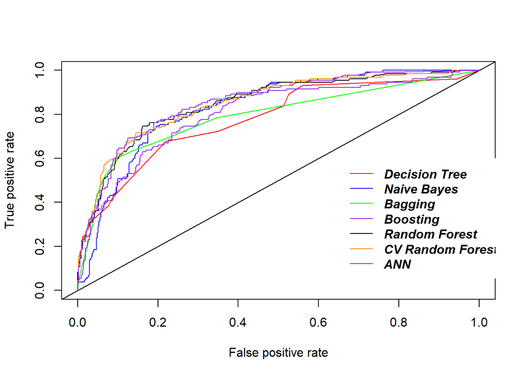

```r
#Calculating Type I Error
T1.ann <- CM.ann$table[3] / (CM.ann$table[3] + CM.ann$table[4])

#Calculating Type II Error
T2.ann <- 1 - (CM.ann$table[1] / (CM.ann$table[1] + CM.ann$table[2]))

#Calculating True Positive Rate
TP.ann <- 1 - T2.ann

#Calculating True Negative Rate
TN.ann <- 1 - T1.ann

#Constructing ROC Curve
WAUSpredann <- ROCR::prediction(prob.ann, ann.test$RainTomorrow)
WAUSperfann <- performance(WAUSpredann, "tpr", "fpr")

#Plot ROC for All Classifiers
{plot(WAUSperftree, col = "red")
 abline(0, 1)
 plot(WAUSperfbayes, add = TRUE, col = "blue")
 plot(WAUSperfbag, add = TRUE, col = "green")
 plot(WAUSperfboost, add = TRUE, col = "purple")
 plot(WAUSperfrf, add = TRUE, col = "black")
 plot(WAUSperfcvrf, add = TRUE, col = "darkorange")
 plot(WAUSperfann, add = TRUE, col = "blueviolet")
 legend(x = 0.65, y = 0.6, lty = 1, legend = c("Decision Tree", "Naive Bayes", "Bagging", "Boosting", "Random Forest", "CV Random Forest", "ANN"), col = c("red", "blue", "green", "purple", "black", "darkorange", "blueviolet"), text.font = 4, box.lty = 0)
}
```

ROC curve for all classifiers and ANN are plotted in figure above.

```r
#Calculating AUC
AUC.ann <- performance(WAUSpredann, "auc")
AUC.ann <- round(as.numeric(AUC.ann@y.values), 4)

#Constructing Summary Table for ANN
t7 <- rbind(CM.ann$overall['Accuracy'], CM.ann$byClass['Pos Pred Value'], CM.ann$byClass['Sensitivity'], CM.ann$byClass['F1'], T1.ann, T2.ann, TP.ann, TN.ann)

#Summary Table for All Classifiers
summary.table2 <- cbind(t6[1:8, ], t7[1:8, ])
AUC.table2 <- cbind(AUC.cvrf, AUC.ann)
summary.table2 <- rbind(summary.table2, AUC.table2)
summary.table2 <- round(summary.table2, 4)

colnames(summary.table2) <- c("CV Random Forest", "ANN")
rownames(summary.table2) <- c("Accuracy", "Precision", "Recall", "F1", "Type I Error", "Type II Error", "True Positive", "True Negative", "AUC")
#Identify the Highest Value among the 6 Classifiers
row <- seq_len(ncol(summary.table2))

{
max.acc <- which.max(summary.table2[1, ])
summary.table2[1, ] <- summary.table2[1, ] %>% cell_spec(bold = row == max.acc)

max.prec <- which.max(summary.table2[2, ])
summary.table2[2, ] <- summary.table2[2, ] %>% cell_spec(bold = row == max.prec)

max.rec <- which.max(summary.table2[3, ])
summary.table2[3, ] <- summary.table2[3, ] %>% cell_spec(bold = row == max.rec)

max.f1 <- which.max(summary.table2[4, ])
summary.table2[4, ] <- summary.table2[4, ] %>% cell_spec(bold = row == max.f1)

max.tp <- which.max(summary.table2[7, ])
summary.table2[7, ] <- summary.table2[7, ] %>% cell_spec(bold = row == max.tp)

max.tn <- which.max(summary.table2[8, ])
summary.table2[8, ] <- summary.table2[8, ] %>% cell_spec(bold = row == max.tn)

max.auc <- which.max(summary.table2[9, ])
summary.table2[9, ] <- summary.table2[9, ] %>% cell_spec(bold = row == max.auc)

#Identify the Smallest Value among the 5 Classifiers
min.t1 <- which.min(summary.table2[5, ])
summary.table2[5, ] <- summary.table2[5, ] %>% cell_spec(bold = row == min.t1)

min.t2 <- which.min(summary.table2[6, ])
summary.table2[6, ] <- summary.table2[6, ] %>% cell_spec(bold = row == min.t2)
}

summary.table2 %>% kable(booktabs = TRUE, escape = FALSE) %>% kable_styling("responsive")
```

|  | CV Random Forest | ANN |
| --- | --- | --- |
| Accuracy | 0.8383 | 0.84 |
| Precision | 0.8607 | 0.8848 |
| Recall | 0.9468 | 0.9149 |
| F1 | 0.9017 | 0.8996 |
| Type I Error | 0.5538 | 0.4308 |
| Type II Error | 0.0532 | 0.0851 |
| True Positive | 0.9468 | 0.9149 |
| True Negative | 0.4462 | 0.5692 |
| AUC | 0.8511 | 0.8385 |

Based on the table above, the results are mixed, but cross-validated random forest is chosen as a better model among the two. This decision is made on the reason that, in general, optimizing for recall, F1-Score and AUC is more important than precision and accuracy for imbalanced dataset.

In an imbalanced dataset, where one class is much more prevalent than the other, simply predicting the majority class can lead to a high accuracy rate but it does not necessarily mean the model is performing well. This is because the model is not adequately identifying the minority class, which may be the class of interest.

In this case, optimizing precision may not be as important as it could lead to many false negatives, which means missing actual positive cases. However, optimizing recall and F1 score can help in identifying more true positives and minimize false negatives, which is especially important in cases where the cost of a false negative is high.

Similarly, AUC takes into account the performance of the model across a range of different threshold values, making it a useful metric for imbalanced datasets. AUC measures the ability of the model to correctly rank true positives and true negatives against false positives and false negatives, making it a good metric to evaluate the overall performance of the model on the imbalanced dataset. In this case, the model that dominates in terms of recall, F1-Score and AUC, which is the **cross-validated random forest**, is chosen as the current best model.

Although ANN is expected to dominate cross-validate random forest in terms of performance, the outcome seems to tell the opposite. This might probably due to the amount of data used to train the model is not large enough.

## Imbalance Data

Another possible consideration is the class imbalance of the training dataset.

```r
prop.table(table(WAUS.train$RainTomorrow))
```

```
##
##        No       Yes
## 0.7914286 0.2085714
```

As shown in the table above, majority of the data is in the class ‘No’. Common approach when dealing with imbalance data is to undersample the majority class and oversample the minority class, but this method is not applied in this case. This is because the imbalance training data actually reflects the reality more accurately, as raining doesn’t occur as frequent as non-rainy days. In this case, methods that can deal with imbalance dataset is proposed.

**Cost-Sensitive Learning** is a technique used to modify the standard classification algorithms to account for the asymmetric costs of misclassification errors. We attempt to implement cost-sensitive learning to the current best model, CV Random Forest. To apply cost-sensitive learning in random forest, one can adjust the class weights parameter in the algorithm. The class weights are used to adjust the importance of each class during the model training process. In the case of imbalanced data, where one class is more dominant than the other, assigning higher weights to the minority class will increase its importance during model training.

The class weights are determined based on inverse class frequencies, where the weights of one class is the proportion of the other class. Cross validation on $mtry$ is peformed again to determine the optimal value by taking class weights into considerations.

```r
#Grid Search
set.seed(100)
trctrl <- trainControl(method = "repeatedcv", number = 10, repeats = 3, search = "grid")
tunegrid <- expand.grid(mtry = (1:15))
weight.cvrf.grid <- train(RainTomorrow ~ ., data = WAUS.train, method = "rf", metric = 'Accuracy', tuneGrid = tunegrid, trControl = trctrl, classwt = c('No' = 0.2, 'Yes' = 0.8))
print(weight.cvrf.grid)
```

```
## Random Forest
##
## 1400 samples
##   16 predictor
##    2 classes: 'No', 'Yes'
##
## No pre-processing
## Resampling: Cross-Validated (10 fold, repeated 3 times)
## Summary of sample sizes: 1260, 1260, 1260, 1260, 1261, 1261, ...
## Resampling results across tuning parameters:
##
##   mtry  Accuracy   Kappa
##    1    0.2085675  0.0000000
##    2    0.6861761  0.3392707
##    3    0.8307035  0.4605141
##    4    0.8449979  0.4296999
##    5    0.8466798  0.4126220
##    6    0.8464452  0.4077109
##    7    0.8457291  0.4013339
##    8    0.8438278  0.3970333
##    9    0.8433465  0.3943136
##   10    0.8426373  0.3923904
##   11    0.8450148  0.4035583
##   12    0.8447819  0.4035943
##   13    0.8454910  0.4118678
##   14    0.8447699  0.4106449
##   15    0.8450098  0.4145036
##
## Accuracy was used to select the optimal model using the largest value.
## The final value used for the model was mtry = 5.
```

With class weight in mind, the optimal $mtry = 5$.

```r
set.seed(100)
WAUS.predwrfgrid <- predict(weight.cvrf.grid, WAUS.test) #Prediction

CM.wrf <- confusionMatrix(mode = "prec_recall", data = WAUS.predwrfgrid, reference = WAUS.test$RainTomorrow) #Confusion Matrix
print(CM.cvrf)
```

```
## Confusion Matrix and Statistics
##
##           Reference
## Prediction  No Yes
##        No  445  72
##        Yes  25  58
##
##                Accuracy : 0.8383
##                  95% CI : (0.8064, 0.8669)
##     No Information Rate : 0.7833
##     P-Value [Acc > NIR] : 0.0004479
##
##                   Kappa : 0.4521
##
##  Mcnemar's Test P-Value : 3.003e-06
##
##               Precision : 0.8607
##                  Recall : 0.9468
##                      F1 : 0.9017
##              Prevalence : 0.7833
##          Detection Rate : 0.7417
##    Detection Prevalence : 0.8617
##       Balanced Accuracy : 0.6965
##
##        'Positive' Class : No
##
```

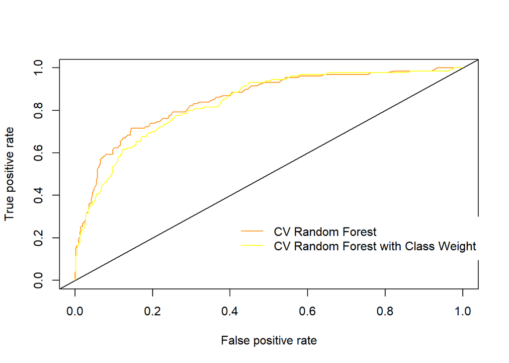

```r
#Calculating Type I Error
T1.wrf <- CM.wrf$table[3] / (CM.wrf$table[3] + CM.wrf$table[4])

#Calculating Type II Error
T2.wrf <- 1 - (CM.wrf$table[1] / (CM.wrf$table[1] + CM.wrf$table[2]))

#Calculating True Positive Rate
TP.wrf <- 1 - T2.wrf

#Calculating True Negative Rate
TN.wrf <- 1 - T1.wrf

#Constructing ROC Curve
WAUS.prob.wrf <- predict(weight.cvrf.grid, WAUS.test, type = "prob")
WAUSpredwrf <- ROCR::prediction(WAUS.prob.wrf[, 2], WAUS.test$RainTomorrow)
WAUSperfwrf <- performance(WAUSpredwrf, "tpr", "fpr")

#Plot ROC for All Classifiers
{plot(WAUSperfcvrf, col = "darkorange")
 abline(0, 1)
 plot(WAUSperfwrf, add = TRUE, col = 'yellow')
 legend(x = 0.4, y = 0.3, lty = 1, legend = c("CV Random Forest", "CV Random Forest with Class Weight"), col = c("darkorange",'yellow'), text.font = 1, box.lty = 0)
}
```

The ROC curve of CV Random Forest and CV Random Forest with Class Weight is shown above.

```r
#Calculating AUC
AUC.wrf <- performance(WAUSpredwrf, "auc")
AUC.wrf <- round(as.numeric(AUC.wrf@y.values), 4)

#Constructing Summary Table for Cross Validated Random Forest with Class Weight
t8 <- rbind(CM.wrf$overall['Accuracy'], CM.wrf$byClass['Pos Pred Value'], CM.wrf$byClass['Sensitivity'], CM.wrf$byClass['F1'], T1.wrf, T2.wrf, TP.wrf, TN.wrf, AUC.wrf)
t8 <- round(t8, 4)

#Comparing Random Forest and CV Random Forest
summary.table3 <- cbind(t6[1:8, ], t8[1:8, ])
AUC.table3 <- cbind(AUC.cvrf, AUC.wrf)
rownames(AUC.table3) <- "AUC"
summary.table3 <- rbind(summary.table3, AUC.table3)
summary.table3 <- round(summary.table3, 4)

colnames(summary.table3) <- c("CV Random Forest", "CV Random Forest with Class Weight")
rownames(summary.table3) <- c("Accuracy", "Precision", "Recall", "F1", "Type I Error", "Type II Error", "True Positive", "True Negative", "AUC")

#Identify the Highest Value between the Two Classifiers
row <- seq_len(ncol(summary.table3))

{
max.acc <- which.max(summary.table3[1, ])
summary.table3[1, ] <- summary.table3[1, ] %>% cell_spec(bold = row == max.acc)

max.prec <- which.max(summary.table3[2, ])
summary.table3[2, ] <- summary.table3[2, ] %>% cell_spec(bold = row == max.prec)

max.rec <- which.max(summary.table3[3, ])
summary.table3[3, ] <- summary.table3[3, ] %>% cell_spec(bold = row == max.rec)

max.f1 <- which.max(summary.table3[4, ])
summary.table3[4, ] <- summary.table3[4, ] %>% cell_spec(bold = row == max.f1)

max.tp <- which.max(summary.table3[7, ])
summary.table3[7, ] <- summary.table3[7, ] %>% cell_spec(bold = row == max.tp)

max.tn <- which.max(summary.table3[8, ])
summary.table3[8, ] <- summary.table3[8, ] %>% cell_spec(bold = row == max.tn)

max.auc <- which.max(summary.table3[9, ])
summary.table3[9, ] <- summary.table3[9, ] %>% cell_spec(bold = row == max.auc)

#Identify the Smallest Value among the 5 Classifiers
min.t1 <- which.min(summary.table3[5, ])
summary.table3[5, ] <- summary.table3[5, ] %>% cell_spec(bold = row == min.t1)

min.t2 <- which.min(summary.table3[6, ])
summary.table3[6, ] <- summary.table3[6, ] %>% cell_spec(bold = row == min.t2)
}

summary.table3 %>% kable(booktabs = TRUE, escape = FALSE) %>% kable_styling("responsive")
```

|  | CV Random Forest | CV Random Forest with Class Weight |
| --- | --- | --- |
| Accuracy | 0.8383 | 0.8233 |
| Precision | 0.8607 | 0.8447 |
| Recall | 0.9468 | 0.9489 |
| F1 | 0.9017 | 0.8938 |
| Type I Error | 0.5538 | 0.6308 |
| Type II Error | 0.0532 | 0.0511 |
| True Positive | 0.9468 | 0.9489 |
| True Negative | 0.4462 | 0.3692 |
| AUC | 0.8511 | 0.8356 |

The model with class weight consideration performs worse than the model without class weight consideration, possibly indicate that the random forest model already account for class imbalance very well. Random forests have an inherent ability to handle class imbalance, and sometimes adding class weights can even reduce the performance of the model.

In this case, **Cross Validated Random Forest** model is chosen as the best model for predicting whether it will rain tomorrow.

After obtaining the best model, it is then applied onto the full dataset of “WAUS2020.csv” to obtain the out-of-sample accuracy of the model. The data used to train and test the model are removed to ensure the data used are new and unseen to the model.

```r
#Ensure the location is the same as the 10 locations we used to train
WAUS.whole = read.csv("WAUS2020.csv")
WAUS.whole <- WAUS.whole[(WAUS.whole$Location %in% L),]

#Remove variables excluded in training
col.remove <- c("Evaporation", "Sunshine", "Cloud9am", "Cloud3pm")
WAUS.whole <- WAUS.whole[, !names(WAUS.whole) %in% col.remove, drop = FALSE]

#Remove rows used in training and testing the model
trainrow <- which(rownames(WAUS.whole) %in% rownames(WAUS.train))
testrow <- which(rownames(WAUS.whole) %in% rownames(WAUS.test))

WAUS.whole <- WAUS.whole[-trainrow, ]
WAUS.whole <- WAUS.whole[-testrow, ]

#Impute Missing Values with MICE Algorithm
tempWAUS.whole <- WAUS.whole %>% mutate(
  WindGustDir = as.factor(WindGustDir),
  WindDir9am = as.factor(WindDir9am),
  WindDir3pm = as.factor(WindDir3pm),
  RainToday = as.factor(RainToday),
  RainTomorrow = as.factor(RainTomorrow)
)

impute <- mice(tempWAUS.whole, maxit = 0)
predMat = imp$predictorMatrix
met = imp$method

#Classify the 5 Categorical Variables into Unordered and Binary
unordered <- c("WindGustDir", "WindDir9am", "WindDir3pm")
binary <- c("RainToday", "RainTomorrow")

#Assign polyreg for Unordered Variables and logreg.boost for Binary Variables
met[unordered] = "polyreg"
met[binary] = "logreg.boot"
met
```

```
##           Day         Month          Year      Location       MinTemp
##         "pmm"         "pmm"         "pmm"            ""         "pmm"
##       MaxTemp      Rainfall   WindGustDir WindGustSpeed    WindDir9am
##         "pmm"         "pmm"     "polyreg"         "pmm"     "polyreg"
##    WindDir3pm  WindSpeed9am  WindSpeed3pm   Humidity9am   Humidity3pm
##     "polyreg"         "pmm"         "pmm"         "pmm"         "pmm"
##   Pressure9am   Pressure3pm       Temp9am       Temp3pm     RainToday
##         "pmm"         "pmm"         "pmm"         "pmm" "logreg.boot"
##  RainTomorrow
## "logreg.boot"
```

```r
#MICE Method to Impute Missing Values
MICE.whole <- mice(tempWAUS.whole, maxit = 5, predictorMatrix = predMat, method = met, print = FALSE)

#Export Imputed Data
comp <- complete(MICE.whole, 1)

#Check Unique Values
sapply(comp, function(y) sum(length(which(is.na(y)))))
```

```
##           Day         Month          Year      Location       MinTemp
##             0             0             0             0             0
##       MaxTemp      Rainfall   WindGustDir WindGustSpeed    WindDir9am
##             0             0             0             0             0
##    WindDir3pm  WindSpeed9am  WindSpeed3pm   Humidity9am   Humidity3pm
##             0             0             0             0             0
##   Pressure9am   Pressure3pm       Temp9am       Temp3pm     RainToday
##             0             0             0             0             0
##  RainTomorrow
##             0
```

```r
WAUS.whole <- comp

#Predict and Produce Confusion Matrix
set.seed(100)
WAUS.whole.pred <- predict(cvrf.grid, WAUS.whole) #Prediction

CM.whole <- confusionMatrix(mode = "prec_recall", data = WAUS.whole.pred, reference = WAUS.whole$RainTomorrow) #Confusion Matrix

cat(paste("Accuracy: ", CM.whole$overall['Accuracy'], "F1: ", CM.whole$byClass['F1']))
```

```
## Accuracy:  0.866833541927409 F1:  0.920110523786641
```